# Application of Bayesian Random Coefficient Models in Modeling Traffic Congestion

September, 26 2017

## Overview

- Introduction
- Research objective
- Methodology
- Data
- Results
- Conclusions

## Introduction

- Random coefficient models best fit data which are nested/clustered
- The correlation within the group can be analyzed
- Unlike indepencence assumption in basic regression models
- Also disperities between the groups can be quantified

## Introduction

- Random coefficient models are also known as:
- Hierarchical models
- Multilevel models
- Mixed-effect models
- Random-effect models
- Varience-component models
- Partial pulled models

## Introduction

- Traffic data like many other social science data are **nested** in nature
- Vehicles in different lanes
- Traffic in different *days of the week*, etc
- As a results **disparties** arise in data characteristics
- May be Monday has different pattern than Wendsday
- May be inside lanes (near median) has **few** vehicles than outside lane (near shoulder)
- Models without accounting these effect lead to **inconsistency conclusion**

## Random coefficient vs. Basic model

**Basic regression**

- Data observations are independent
- Underlying characteristics is combined to a grand mean
- One homogenous model is fitted

**Random coefficient**

- Data observations are nested to their group
- Underlying characteristics are nested in groups
- Heterogenous models are fitted

## Research Objectives

- Modeling the dynamic characteristics of traffic conditions
- Investigate disperity associated with lane lateral loaction
- Also, the effect of day of the week

## Methodology

*Dynamic Modeling of traffic conditions*

- **Markov Chain theory** was used in the analysis
- Only current traffic regime has influence on the next regime
- Mathematically:

\[P_{ij}=(P_{t+1}=j|P_{t}=i)\]

\[P_{ij} = \left[\begin{array} {rr} P_{ff} & P_{fc} \\ P_{cf} & P_{cc} \\ \end{array}\right] \]

## Methodology

- Dynamic Characteristics

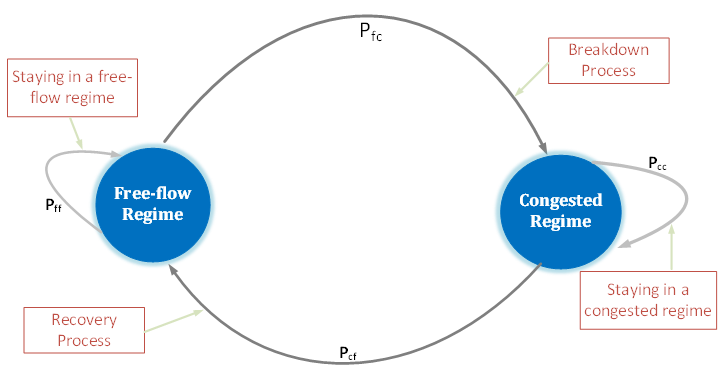

- Markovian Property \[P_{ij} = \left[\begin{array} {rr} P_{ff} & P_{fc} \\ P_{cf} & P_{cc} \\ \end{array}\right] \] where, \[\sum_{j=1}^{2} P_{ij}=1\]

\[P_{ij} = \left[\begin{array} {rr} 1-P_{fc} & P_{fc} \\ 1-P_{cc} & P_{cc} \\ \end{array}\right] \]

## Methodology

**Time-varying effect**

- Regression to model Markov chain Transition probability
- Model is more flexible
- Heterogeneous issue by time is addressed

**Lane and day of the week varying-effect**

- Random coefficient models
- Address heterogenous characteristics associated by lane lateral location
- Address heterogenous characteristics associated by day of the week

## Methodology

- Four series of random coefficient models were developed:
- Varying Intercept Model
- Varying Intercept and Constant Slope Model
- Constant Intercept and Varying Slope Model
- Varying Intercept Model and Varying Slope Model

## Methodology

- Varying Intercept Model and Varying Slope Model

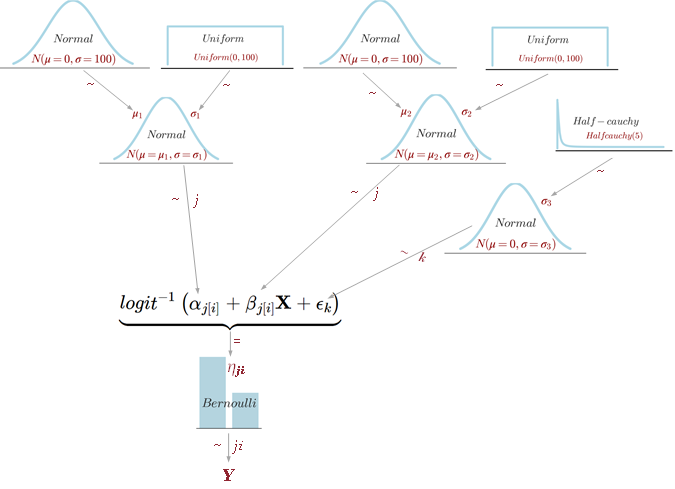

\[ Y_{ij} = Bernoulli(\pi_{ij})\]  
\[ \pi_{ij} = logit^{-1}(\eta_{ij})\] \[ \eta_{ij} = \alpha_{j} + \beta_{j} X + \epsilon_{k}\]

## Methodology

- Varying Intercept Model

\[ Y_{ij} = Bernoulli(\pi_{ij})\]  
\[ \pi_{ij} = logit^{-1}(\eta_{ij})\] \[ \eta_{ij} = \alpha_{j} + \epsilon_{k}\]

- Prior

\[ \alpha_{j} \sim N(\mu_{1}, \sigma_{1})\] \[ \mu_{1} \sim N(\mu=0, \sigma = 100)\]

- Prior \[ \sigma_{1} \sim unif(0, 100)\] \[ \epsilon_{k} \sim N(\mu=0, \sigma = \sigma_{k})\] \[ \sigma_{k} \sim halfcauchy(0, 5)\]

## Methodology

- Varying Intercept and Constant Slope Model

\[ Y_{ij} = Bernoulli(\pi_{ij})\] \[ \pi_{ij} = logit^{-1}(\eta_{ij})\] \[ \eta_{ij} = \alpha_{j} + \beta X + \epsilon_{k}\]

- Prior

\[ \alpha_{j} \sim N(\mu_{1}, \sigma_{1})\] \[ \mu_{1} \sim N(\mu=0, \sigma = 100)\]

- Prior

\[ \sigma_{1} \sim unif(0, 100)\] \[ \beta \sim N(\mu=0, \sigma = 100)\] \[ \epsilon_{k} \sim N(\mu=0, \sigma = \sigma_{k})\] \[ \sigma_{k} \sim halfcauchy(0, 5)\]

## Model Comparison

- Widely Information criterion (WAIC)
- Penalize model with large number of parameters
- Fully Baseyian approach - uncertanity incorporated

\[ WAIC = -2*lppd + 2*pWAIC\]  
where,

```
lppd is the log point-wise posterior density
pWAIC is the effective number of parameters
```

## Results

Model Comparison Results

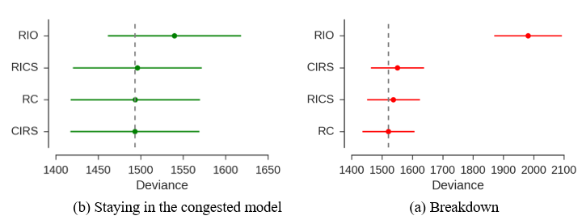

## Results

Model Comparison Results

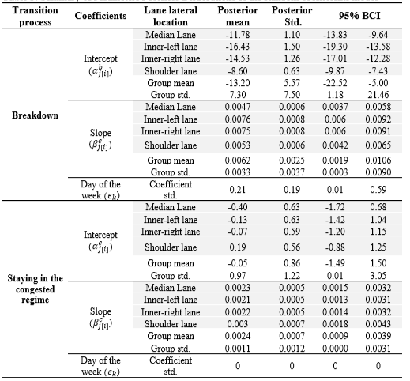

## Results

[output not shown]